# Image Classification

In this project, you'll classify images from the [CIFAR-10 dataset](https://www.cs.toronto.edu/~kriz/cifar.html). The dataset consists of airplanes, dogs, cats, and other objects. You'll preprocess the images, then train a convolutional neural network on all the samples. The images need to be normalized and the labels need to be one-hot encoded. You'll get to apply what you learned and build a convolutional, max pooling, dropout, and fully connected layers. At the end, you'll get to see your neural network's predictions on the sample images.

## Get the Data

Run the following cell to download the [CIFAR-10 dataset for python](https://www.cs.toronto.edu/~kriz/cifar-10-python.tar.gz).

```python
"""
DON'T MODIFY ANYTHING IN THIS CELL THAT IS BELOW THIS LINE
"""
from urllib.request import urlretrieve
from os.path import isfile, isdir
from tqdm import tqdm
import problem_unittests as tests
import tarfile

cifar10_dataset_folder_path = 'cifar-10-batches-py'

# Use Floyd's cifar-10 dataset if present
floyd_cifar10_location = '/input/cifar-10/python.tar.gz'
if isfile(floyd_cifar10_location):
    tar_gz_path = floyd_cifar10_location
else:
    tar_gz_path = 'cifar-10-python.tar.gz'

class DLProgress(tqdm):
    last_block = 0

    def hook(self, block_num=1, block_size=1, total_size=None):
        self.total = total_size
        self.update((block_num - self.last_block) * block_size)
        self.last_block = block_num

if not isfile(tar_gz_path):
    with DLProgress(unit='B', unit_scale=True, miniters=1, desc='CIFAR-10 Dataset') as pbar:
        urlretrieve(
            'https://www.cs.toronto.edu/~kriz/cifar-10-python.tar.gz',
            tar_gz_path,
            pbar.hook)

if not isdir(cifar10_dataset_folder_path):
    with tarfile.open(tar_gz_path) as tar:
        tar.extractall()
        tar.close()


tests.test_folder_path(cifar10_dataset_folder_path)
```

```
CIFAR-10 Dataset: 171MB [01:58, 1.44MB/s]
```

```
All files found!
```

## Explore the Data

The dataset is broken into batches to prevent your machine from running out of memory. The CIFAR-10 dataset consists of 5 batches, named `data_batch_1`, `data_batch_2`, etc.. Each batch contains the labels and images that are one of the following:

- airplane
- automobile
- bird
- cat
- deer
- dog
- frog
- horse
- ship
- truck

Understanding a dataset is part of making predictions on the data. Play around with the code cell below by changing the `batch_id` and `sample_id`. The `batch_id` is the id for a batch (1-5). The `sample_id` is the id for a image and label pair in the batch.

Ask yourself "What are all possible labels?", "What is the range of values for the image data?", "Are the labels in order or random?". Answers to questions like these will help you preprocess the data and end up with better predictions.

```
Stats of batch 1:
Samples: 10000
Label Counts: {0: 1005, 1: 974, 2: 1032, 3: 1016, 4: 999, 5: 937, 6: 1030, 7: 1001, 8: 1025, 9: 981}
First 20 Labels: [6, 9, 9, 4, 1, 1, 2, 7, 8, 3, 4, 7, 7, 2, 9, 9, 9, 3, 2, 6]

Example of Image 5:
Image - Min Value: 0 Max Value: 252
Image - Shape: (32, 32, 3)
Label - Label Id: 1 Name: automobile
```

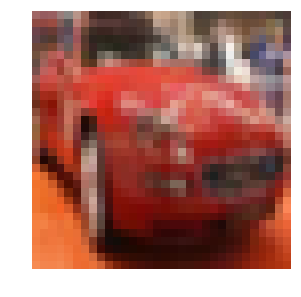

```python
%matplotlib inline
%config InlineBackend.figure_format = 'retina'

import helper
import numpy as np

# Explore the dataset
batch_id = 1
sample_id = 5
helper.display_stats(cifar10_dataset_folder_path, batch_id, sample_id)
```

## Implement Preprocess Functions

### Normalize

In the cell below, implement the `normalize` function to take in image data, `x`, and return it as a normalized Numpy array. The values should be in the range of 0 to 1, inclusive. The return object should be the same shape as `x`.

```python
def normalize(x):
    """
    Normalize a list of sample image data in the range of 0 to 1
    : x: List of image data.  The image shape is (32, 32, 3)
    : return: Numpy array of normalize data
    """
    # TODO: Implement Function
    return np.array([x_i / 255 for x_i in x])


"""
DON'T MODIFY ANYTHING IN THIS CELL THAT IS BELOW THIS LINE
"""
tests.test_normalize(normalize)
```

```
Tests Passed
```

### One-hot encode

Just like the previous code cell, you'll be implementing a function for preprocessing. This time, you'll implement the `one_hot_encode` function. The input, `x`, are a list of labels. Implement the function to return the list of labels as One-Hot encoded Numpy array. The possible values for labels are 0 to 9. The one-hot encoding function should return the same encoding for each value between each call to `one_hot_encode`. Make sure to save the map of encodings outside the function.

Hint: Don't reinvent the wheel.

```python
from sklearn.preprocessing import LabelBinarizer

def fit_label_binarizer():
    unique_labels = set()
    for batch_i in np.arange(1, 5 + 1):
        _, labels = helper.load_cfar10_batch(cifar10_dataset_folder_path, 1)
        unique_labels.update(labels)
    return LabelBinarizer().fit(list(unique_labels))

label_binarizer = fit_label_binarizer()

def one_hot_encode(x):
    """
    One hot encode a list of sample labels. Return a one-hot encoded vector for each label.
    : x: List of sample Labels
    : return: Numpy array of one-hot encoded labels
    """
    # TODO: Implement Function
    return label_binarizer.transform(x)


"""
DON'T MODIFY ANYTHING IN THIS CELL THAT IS BELOW THIS LINE
"""
tests.test_one_hot_encode(one_hot_encode)
```

```
Tests Passed
```

### Randomize Data

As you saw from exploring the data above, the order of the samples are randomized. It doesn't hurt to randomize it again, but you don't need to for this dataset.

## Preprocess all the data and save it

Running the code cell below will preprocess all the CIFAR-10 data and save it to file. The code below also uses 10% of the training data for validation.

```python
"""
DON'T MODIFY ANYTHING IN THIS CELL
"""
# Preprocess Training, Validation, and Testing Data
helper.preprocess_and_save_data(cifar10_dataset_folder_path, normalize, one_hot_encode)
```

# Check Point

This is your first checkpoint. If you ever decide to come back to this notebook or have to restart the notebook, you can start from here. The preprocessed data has been saved to disk.

```python
"""
DON'T MODIFY ANYTHING IN THIS CELL
"""
import pickle
import problem_unittests as tests
import helper

# Load the Preprocessed Validation data
valid_features, valid_labels = pickle.load(open('preprocess_validation.p', mode='rb'))
```

## Build the network

For the neural network, you'll build each layer into a function. Most of the code you've seen has been outside of functions. To test your code more thoroughly, we require that you put each layer in a function. This allows us to give you better feedback and test for simple mistakes using our unittests before you submit your project.

> **Note:** If you're finding it hard to dedicate enough time for this course each week, we've provided a small shortcut to this part of the project. In the next couple of problems, you'll have the option to use classes from the [TensorFlow Layers](https://www.tensorflow.org/api_docs/python/tf/layers) or [TensorFlow Layers (contrib)](https://www.tensorflow.org/api_guides/python/contrib.layers) packages to build each layer, except the layers you build in the "Convolutional and Max Pooling Layer" section. TF Layers is similar to Keras's and TFLearn's abstraction to layers, so it's easy to pickup.

> However, if you would like to get the most out of this course, try to solve all the problems *without* using anything from the TF Layers packages. You **can** still use classes from other packages that happen to have the same name as ones you find in TF Layers! For example, instead of using the TF Layers version of the `conv2d` class, [tf.layers.conv2d](https://www.tensorflow.org/api_docs/python/tf/layers/conv2d), you would want to use the TF Neural Network version of `conv2d`, [tf.nn.conv2d](https://www.tensorflow.org/api_docs/python/tf/nn/conv2d).

Let's begin!

### Input

The neural network needs to read the image data, one-hot encoded labels, and dropout keep probability. Implement the following functions

- Implement `neural_net_image_input`
  - Return a [TF Placeholder](https://www.tensorflow.org/api_docs/python/tf/placeholder)
  - Set the shape using `image_shape` with batch size set to `None`.
  - Name the TensorFlow placeholder "x" using the TensorFlow `name` parameter in the [TF Placeholder](https://www.tensorflow.org/api_docs/python/tf/placeholder).
- Implement `neural_net_label_input`
  - Return a [TF Placeholder](https://www.tensorflow.org/api_docs/python/tf/placeholder)
  - Set the shape using `n_classes` with batch size set to `None`.
  - Name the TensorFlow placeholder "y" using the TensorFlow `name` parameter in the [TF Placeholder](https://www.tensorflow.org/api_docs/python/tf/placeholder).
- Implement `neural_net_keep_prob_input`
  - Return a [TF Placeholder](https://www.tensorflow.org/api_docs/python/tf/placeholder) for dropout keep probability.
  - Name the TensorFlow placeholder "keep_prob" using the TensorFlow `name` parameter in the [TF Placeholder](https://www.tensorflow.org/api_docs/python/tf/placeholder).

These names will be used at the end of the project to load your saved model.

Note: `None` for shapes in TensorFlow allow for a dynamic size.

```python
import tensorflow as tf
import numpy as np

tf.reset_default_graph()

def neural_net_image_input(image_shape):
    """
    Return a Tensor for a batch of image input
    : image_shape: Shape of the images
    : return: Tensor for image input.
    """
    # TODO: Implement Function
    shape = [None] + list(image_shape)
    return tf.placeholder(tf.float32, shape=shape, name='x')


def neural_net_label_input(n_classes):
    """
    Return a Tensor for a batch of label input
    : n_classes: Number of classes
    : return: Tensor for label input.
    """
    # TODO: Implement Function
    return tf.placeholder(tf.int32, shape=[None, n_classes], name='y')


def neural_net_keep_prob_input():
    """
    Return a Tensor for keep probability
    : return: Tensor for keep probability.
    """
    # TODO: Implement Function
    return tf.placeholder(tf.float32, name='keep_prob')


"""
DON'T MODIFY ANYTHING IN THIS CELL THAT IS BELOW THIS LINE
"""
tf.reset_default_graph()
tests.test_nn_image_inputs(neural_net_image_input)
tests.test_nn_label_inputs(neural_net_label_input)
tests.test_nn_keep_prob_inputs(neural_net_keep_prob_input)
```

```
Image Input Tests Passed.
Label Input Tests Passed.
Keep Prob Tests Passed.
```

### Convolution and Max Pooling Layer

Convolution layers have a lot of success with images. For this code cell, you should implement the function `conv2d_maxpool` to apply convolution then max pooling:

- Create the weight and bias using `conv_ksize`, `conv_num_outputs` and the shape of `x_tensor`.
- Apply a convolution to `x_tensor` using weight and `conv_strides`.
  - We recommend you use same padding, but you're welcome to use any padding.
- Add bias
- Add a nonlinear activation to the convolution.
- Apply Max Pooling using `pool_ksize` and `pool_strides`.
  - We recommend you use same padding, but you're welcome to use any padding.

**Note:** You **can't** use [TensorFlow Layers](https://www.tensorflow.org/api_docs/python/tf/layers) or [TensorFlow Layers (contrib)](https://www.tensorflow.org/api_guides/python/contrib.layers) for **this** layer, but you can still use TensorFlow's [Neural Network](https://www.tensorflow.org/api_docs/python/tf/nn) package. You may still use the shortcut option for all the **other** layers.

```python
def conv2d_maxpool(x_tensor, conv_num_outputs, conv_ksize, conv_strides, pool_ksize, pool_strides, padding='SAME'):
    """
    Apply convolution then max pooling to x_tensor
    :param x_tensor: TensorFlow Tensor
    :param conv_num_outputs: Number of outputs for the convolutional layer
    :param conv_ksize: kernal size 2-D Tuple for the convolutional layer
    :param conv_strides: Stride 2-D Tuple for convolution
    :param pool_ksize: kernal size 2-D Tuple for pool
    :param pool_strides: Stride 2-D Tuple for pool
    : return: A tensor that represents convolution and max pooling of x_tensor
    """
    # TODO: Implement Function
    num_chanels = x_tensor.get_shape().as_list()[-1]
    weights = tf.Variable(tf.truncated_normal([conv_ksize[0], conv_ksize[1],
                                               num_chanels, conv_num_outputs], stddev=0.1))
    bias = tf.Variable(tf.zeros([conv_num_outputs]))

    layer = tf.nn.conv2d(
        x_tensor,
        weights,
        [1, conv_strides[0], conv_strides[1], 1],
        padding
    )
    layer = tf.nn.bias_add(layer, bias)
    layer = tf.nn.max_pool(
        layer,
        [1, pool_ksize[0], pool_ksize[1], 1],
        [1, pool_strides[0], pool_strides[1], 1],
        padding
    )
    return tf.nn.relu(layer)

def conv2d_conv2d_maxpool(x_tensor, conv_num_outputs, conv_ksize, conv_strides, pool_ksize, pool_strides, padding='SAME'):
    """
    Apply convolution twice then max pooling to x_tensor
    :param x_tensor: TensorFlow Tensor
    :param conv_num_outputs: Number of outputs for the convolutional layer
    :param conv_ksize: kernal size 2-D Tuple for the convolutional layer
    :param conv_strides: Stride 2-D Tuple for convolution
    :param pool_ksize: kernal size 2-D Tuple for pool
    :param pool_strides: Stride 2-D Tuple for pool
    : return: A tensor that represents convolution and max pooling of x_tensor
    """
    # TODO: Implement Function
    num_chanels = x_tensor.get_shape().as_list()[-1]
    # conv 1
    weights = tf.Variable(tf.truncated_normal([conv_ksize[0], conv_ksize[1],
                                               num_chanels, conv_num_outputs], stddev=0.1))
    bias = tf.Variable(tf.zeros([conv_num_outputs]))

    layer = tf.nn.conv2d(
        x_tensor,
        weights,
        [1, conv_strides[0], conv_strides[1], 1],
        padding
    )
    layer = tf.nn.bias_add(layer, bias)
    # relu
    layer = tf.nn.relu(layer)
    # conv 2
    weights = tf.Variable(tf.truncated_normal([conv_ksize[0], conv_ksize[1],
                                               conv_num_outputs, conv_num_outputs], stddev=0.1))
    bias = tf.Variable(tf.zeros([conv_num_outputs]))

    layer = tf.nn.conv2d(
        layer,
        weights,
        [1, conv_strides[0], conv_strides[1], 1],
        padding
    )
    layer = tf.nn.bias_add(layer, bias)
    # maxpool
    layer = tf.nn.max_pool(
        layer,
        [1, pool_ksize[0], pool_ksize[1], 1],
        [1, pool_strides[0], pool_strides[1], 1],
        padding
    )
    # relu
    return tf.nn.relu(layer)


"""
DON'T MODIFY ANYTHING IN THIS CELL THAT IS BELOW THIS LINE
"""
tests.test_con_pool(conv2d_maxpool)
```

```
Tests Passed
```

### Flatten Layer

Implement the `flatten` function to change the dimension of `x_tensor` from a 4-D tensor to a 2-D tensor. The output should be the shape (*Batch Size*, *Flattened Image Size*). Shortcut option: you can use classes from the [TensorFlow Layers](https://www.tensorflow.org/api_docs/python/tf/layers) or [TensorFlow Layers (contrib)](https://www.tensorflow.org/api_guides/python/contrib.layers) packages for this layer. For more of a challenge, only use other TensorFlow packages.

```python
def flatten(x_tensor):
    """
    Flatten x_tensor to (Batch Size, Flattened Image Size)
    : x_tensor: A tensor of size (Batch Size, ...), where ... are the image dimensions.
    : return: A tensor of size (Batch Size, Flattened Image Size).
    """
    # TODO: Implement Function
    # _, d2, d3, d4 = x_tensor.get_shape().as_list()
    # return tf.reshape(x_tensor, [-1, d2 * d3 * d4])
    return tf.contrib.layers.flatten(x_tensor)



"""
DON'T MODIFY ANYTHING IN THIS CELL THAT IS BELOW THIS LINE
"""
tests.test_flatten(flatten)
```

```
Tests Passed
```

### Fully-Connected Layer

Implement the `fully_conn` function to apply a fully connected layer to `x_tensor` with the shape (*Batch Size*, *num_outputs*). Shortcut option: you can use classes from the [TensorFlow Layers](https://www.tensorflow.org/api_docs/python/tf/layers) or [TensorFlow Layers (contrib)](https://www.tensorflow.org/api_guides/python/contrib.layers) packages for this layer. For more of a challenge, only use other TensorFlow packages.

```python
def fully_conn(x_tensor, num_outputs):
    """
    Apply a fully connected layer to x_tensor using weight and bias
    : x_tensor: A 2-D tensor where the first dimension is batch size.
    : num_outputs: The number of output that the new tensor should be.
    : return: A 2-D tensor where the second dimension is num_outputs.
    """
    # TODO: Implement Function
    weights = tf.Variable(tf.truncated_normal([x_tensor.get_shape().as_list()[1], num_outputs], stddev=0.1))
    bias = tf.Variable(tf.zeros([num_outputs]))

    return tf.nn.relu(tf.add(tf.matmul(x_tensor, weights), bias))


"""
DON'T MODIFY ANYTHING IN THIS CELL THAT IS BELOW THIS LINE
"""
tests.test_fully_conn(fully_conn)
```

```
Tests Passed
```

### Output Layer

Implement the `output` function to apply a fully connected layer to `x_tensor` with the shape (*Batch Size*, *num_outputs*). Shortcut option: you can use classes from the [TensorFlow Layers](https://www.tensorflow.org/api_docs/python/tf/layers) or [TensorFlow Layers (contrib)](https://www.tensorflow.org/api_guides/python/contrib.layers) packages for this layer. For more of a challenge, only use other TensorFlow packages.

**Note:** Activation, softmax, or cross entropy should **not** be applied to this.

```python
def output(x_tensor, num_outputs):
    """
    Apply a output layer to x_tensor using weight and bias
    : x_tensor: A 2-D tensor where the first dimension is batch size.
    : num_outputs: The number of output that the new tensor should be.
    : return: A 2-D tensor where the second dimension is num_outputs.
    """
    # TODO: Implement Function
    weights = tf.Variable(tf.truncated_normal([x_tensor.get_shape().as_list()[1], num_outputs], stddev=0.1))
    bias = tf.Variable(tf.zeros([num_outputs]))

    return tf.add(tf.matmul(x_tensor, weights), bias)


"""
DON'T MODIFY ANYTHING IN THIS CELL THAT IS BELOW THIS LINE
"""
tests.test_output(output)
```

```
Tests Passed
```

### Create Convolutional Model

Implement the function `conv_net` to create a convolutional neural network model. The function takes in a batch of images, `x`, and outputs logits. Use the layers you created above to create this model:

- Apply 1, 2, or 3 Convolution and Max Pool layers
- Apply a Flatten Layer
- Apply 1, 2, or 3 Fully Connected Layers
- Apply an Output Layer
- Return the output
- Apply [TensorFlow's Dropout](https://www.tensorflow.org/api_docs/python/tf/nn/dropout) to one or more layers in the model using `keep_prob`.

```python
# LeNet5
# def conv_net(x, keep_prob):
#     """
#     Create a convolutional neural network model
#     : x: Placeholder tensor that holds image data.
#     : keep_prob: Placeholder tensor that hold dropout keep probability.
#     : return: Tensor that represents logits
#     """
#     # TODO: Apply 1, 2, or 3 Convolution and Max Pool layers
#     #    Play around with different number of outputs, kernel size and stride
#     # Function Definition from Above:
#     #    conv2d_maxpool(x_tensor, conv_num_outputs, conv_ksize, conv_strides, pool_ksize, pool_strides)
#     conv_1 = conv2d_maxpool(x, 6, [5, 5], [1, 1], [2, 2], [2, 2], 'VALID')
#     conv_2 = conv2d_maxpool(conv_1, 16, [5, 5], [1, 1], [2, 2], [2, 2], 'VALID')

#     # TODO: Apply a Flatten Layer
#     # Function Definition from Above:
#     #   flatten(x_tensor)
#     layer = flatten(conv_2)

#     # TODO: Apply 1, 2, or 3 Fully Connected Layers
#     #    Play around with different number of outputs
#     # Function Definition from Above:
#     #   fully_conn(x_tensor, num_outputs)
#     fc_1 = fully_conn(layer, 120)
#     fc_2 = fully_conn(fc_1, 84)

#     # TODO: Apply an Output Layer
#     #    Set this to the number of classes
#     # Function Definition from Above:
#     #   output(x_tensor, num_outputs)
#     layer = tf.nn.dropout(fc_2, keep_prob)

#     # TODO: return output
#     return output(layer, 10)

# 0.77
# def conv_net(x, keep_prob):
#     """
#     Create a convolutional neural network model
#     : x: Placeholder tensor that holds image data.
#     : keep_prob: Placeholder tensor that hold dropout keep probability.
#     : return: Tensor that represents logits
#     """
#     # TODO: Apply 1, 2, or 3 Convolution and Max Pool layers
#     #    Play around with different number of outputs, kernel size and stride
#     # Function Definition from Above:
#     #    conv2d_maxpool(x_tensor, conv_num_outputs, conv_ksize, conv_strides, pool_ksize, pool_strides)
#     conv_1 = conv2d_maxpool(x, 64, [5, 5], [1, 1], [3, 3], [2, 2], 'SAME')
#     norm1 = tf.nn.lrn(conv_1, 4, bias=1.0, alpha=0.001 / 9.0, beta=0.75)
#     conv_2 = conv2d_maxpool(norm1, 64, [5, 5], [1, 1], [3, 3], [2, 2], 'SAME')

#     # TODO: Apply a Flatten Layer
#     # Function Definition from Above:
#     #   flatten(x_tensor)
#     layer = flatten(conv_2)

#     # TODO: Apply 1, 2, or 3 Fully Connected Layers
#     #    Play around with different number of outputs
#     # Function Definition from Above:
#     #   fully_conn(x_tensor, num_outputs)
#     fc_1 = fully_conn(layer, 384)
#     fc_1 = tf.nn.dropout(fc_1, keep_prob)
#     fc_2 = fully_conn(fc_1, 192)
#     fc_2 = tf.nn.dropout(fc_2, keep_prob)

#     # TODO: Apply an Output Layer
#     #    Set this to the number of classes
#     # Function Definition from Above:
#     #   output(x_tensor, num_outputs)
#     output_layer = output(fc_2, 10)

#     # TODO: return output
#     return output_layer

def conv_net(x, keep_prob):
    """
    Create a convolutional neural network model
    : x: Placeholder tensor that holds image data.
    : keep_prob: Placeholder tensor that hold dropout keep probability.
    : return: Tensor that represents logits
    """
    # TODO: Apply 1, 2, or 3 Convolution and Max Pool layers
    #    Play around with different number of outputs, kernel size and stride
    # Function Definition from Above:
    #    conv2d_maxpool(x_tensor, conv_num_outputs, conv_ksize, conv_strides, pool_ksize, pool_strides)
    conv_1 = conv2d_conv2d_maxpool(x, 64, [3, 3], [1, 1], [2, 2], [2, 2], 'SAME')
    norm1 = tf.nn.lrn(conv_1, 4, bias=1.0, alpha=0.001 / 9.0, beta=0.75)
    conv_2 = conv2d_conv2d_maxpool(norm1, 64, [3, 3], [1, 1], [2, 2], [2, 2], 'SAME')

    # TODO: Apply a Flatten Layer
    # Function Definition from Above:
    #   flatten(x_tensor)
    layer = flatten(conv_2)

    # TODO: Apply 1, 2, or 3 Fully Connected Layers
    #    Play around with different number of outputs
    # Function Definition from Above:
    #   fully_conn(x_tensor, num_outputs)
    fc_1 = fully_conn(layer, 384)
    fc_1 = tf.nn.dropout(fc_1, keep_prob)
    fc_2 = fully_conn(fc_1, 192)
    fc_2 = tf.nn.dropout(fc_2, keep_prob)

    # TODO: Apply an Output Layer
    #    Set this to the number of classes
    # Function Definition from Above:
    #   output(x_tensor, num_outputs)
    output_layer = output(fc_2, 10)

    # TODO: return output
    return output_layer


"""
DON'T MODIFY ANYTHING IN THIS CELL THAT IS BELOW THIS LINE
"""

##############################
## Build the Neural Network ##
##############################

# Remove previous weights, bias, inputs, etc..
tf.reset_default_graph()

# Inputs
x = neural_net_image_input((32, 32, 3))
y = neural_net_label_input(10)
keep_prob = neural_net_keep_prob_input()

# Model
logits = conv_net(x, keep_prob)

# Name logits Tensor, so that is can be loaded from disk after training
logits = tf.identity(logits, name='logits')

# Loss and Optimizer
cost = tf.reduce_mean(tf.nn.softmax_cross_entropy_with_logits(logits=logits, labels=y))
optimizer = tf.train.AdamOptimizer().minimize(cost)

# Accuracy
correct_pred = tf.equal(tf.argmax(logits, 1), tf.argmax(y, 1))
accuracy = tf.reduce_mean(tf.cast(correct_pred, tf.float32), name='accuracy')

tests.test_conv_net(conv_net)
```

```
Neural Network Built!
```

## Train the Neural Network

### Single Optimization

Implement the function `train_neural_network` to do a single optimization. The optimization should use `optimizer` to optimize in `session` with a `feed_dict` of the following:

- `x` for image input
- `y` for labels
- `keep_prob` for keep probability for dropout

This function will be called for each batch, so `tf.global_variables_initializer()` has already been called.

Note: Nothing needs to be returned. This function is only optimizing the neural network.

```python
def train_neural_network(session, optimizer, keep_probability, feature_batch, label_batch):
    """
    Optimize the session on a batch of images and labels
    : session: Current TensorFlow session
    : optimizer: TensorFlow optimizer function
    : keep_probability: keep probability
    : feature_batch: Batch of Numpy image data
    : label_batch: Batch of Numpy label data
    """
    # TODO: Implement Function
    session.run(optimizer, feed_dict={
                    x: feature_batch,
                    y: label_batch,
                    keep_prob: keep_probability
                })


"""
DON'T MODIFY ANYTHING IN THIS CELL THAT IS BELOW THIS LINE
"""
tests.test_train_nn(train_neural_network)
```

```
Tests Passed
```

### Show Stats

Implement the function `print_stats` to print loss and validation accuracy. Use the global variables `valid_features` and `valid_labels` to calculate validation accuracy. Use a keep probability of `1.0` to calculate the loss and validation accuracy.

```python
def calc_stats(session, feature_batch, label_batch, cost, accuracy):
    """
    Print information about loss and validation accuracy
    : session: Current TensorFlow session
    : feature_batch: Batch of Numpy image data
    : label_batch: Batch of Numpy label data
    : cost: TensorFlow cost function
    : accuracy: TensorFlow accuracy function
    """
    return session.run([cost, accuracy], feed_dict={
                    x: feature_batch,
                    y: label_batch,
                    keep_prob: 1.0})

def print_stats(session, feature_batch, label_batch, cost, accuracy):
    """
    Print information about loss and validation accuracy
    : session: Current TensorFlow session
    : feature_batch: Batch of Numpy image data
    : label_batch: Batch of Numpy label data
    : cost: TensorFlow cost function
    : accuracy: TensorFlow accuracy function
    """
    # TODO: Implement Function
    train_loss, train_acc = calc_stats(session, feature_batch, label_batch, cost, accuracy)
    valid_loss, valid_acc = calc_stats(session, valid_features, valid_labels, cost, accuracy)

    print('Train Loss: {:>2.4f} Valid Loss: {:>2.4f} Train Acc: {:.6f} Valid Acc: {:.6f}'
          .format(train_loss, valid_loss, train_acc, valid_acc))
```

### Hyperparameters

Tune the following parameters:

- Set `epochs` to the number of iterations until the network stops learning or start overfitting
- Set `batch_size` to the highest number that your machine has memory for. Most people set them to common sizes of memory:
  - 64
  - 128
  - 256
  - ...
- Set `keep_probability` to the probability of keeping a node using dropout

```python
# TODO: Tune Parameters
epochs = 250
batch_size = 128
keep_probability = 0.5
```

### Train on a Single CIFAR-10 Batch

Instead of training the neural network on all the CIFAR-10 batches of data, let's use a single batch. This should save time while you iterate on the model to get a better accuracy. Once the final validation accuracy is 50% or greater, run the model on all the data in the next section.

```python
"""
DON'T MODIFY ANYTHING IN THIS CELL
"""
print('Checking the Training on a Single Batch...')
session_config = tf.ConfigProto(log_device_placement=True)
with tf.Session(config=session_config) as sess:
    # Initializing the variables
    sess.run(tf.global_variables_initializer())

    # Training cycle
    for epoch in range(epochs):
        batch_i = 1
        for batch_features, batch_labels in helper.load_preprocess_training_batch(batch_i, batch_size):
            train_neural_network(sess, optimizer, keep_probability, batch_features, batch_labels)
        print('Epoch {:>2}, CIFAR-10 Batch {}:  '.format(epoch + 1, batch_i), end='')
        print_stats(sess, batch_features, batch_labels, cost, accuracy)
```

[output not shown]

### Fully Train the Model

```python
"""
DON'T MODIFY ANYTHING IN THIS CELL
"""
import time
import multiprocessing as mp
import pandas as pd
import matplotlib.pyplot as plt
from tflearn.data_augmentation import ImageAugmentation

%matplotlib notebook
%config InlineBackend.figure_format = 'retina'

# it's a computational bottleneck, augementation should be done in ||
img_aug = ImageAugmentation()
img_aug.add_random_flip_leftright()
img_aug.add_random_rotation(max_angle=25.)
img_aug.add_random_blur(sigma_max=3.)

save_model_path = './image_classification'
checkpoint_epoch = None
best_valid_acc_so_far = 0
best_valid_loss_so_far = 1e6
train_stats = pd.DataFrame(columns=['train_loss', 'valid_loss', 'train_acc', 'valid_acc'])

def plot_train_stats(train_stats):
    fig = plt.figure(figsize=(18, 6))
    ax = plt.subplot(1, 2, 1)
    train_stats[['train_loss', 'valid_loss']].plot(title='Loss', ax=ax)
    ax = plt.subplot(1, 2, 2)
    train_stats[['train_acc', 'valid_acc']].plot(title='Accuracy', ax=ax)

fig, (loss_ax, acc_ax) = plt.subplots(1, 2, figsize=(9, 4), sharex=True)
fig.canvas.set_window_title('Train stats')

def update_plot():
    if epoch == 0:
        train_stats[['train_loss', 'valid_loss']].plot(title='Loss', ax=loss_ax)
        train_stats[['train_acc', 'valid_acc']].plot(title='Accuracy', ax=acc_ax)

        plt.show()
    else:
        for ax in [loss_ax, acc_ax]:
            columns = []
            for line in ax.lines:
                line_name = line.get_label()
                columns.append(line_name)

                x_data, y_data = line.get_xdata(), line.get_ydata()

                x_data = np.append(x_data, epoch + 1)
                y_data = np.append(y_data, train_stats[line_name].values[-1])

                line.set_xdata(x_data)
                line.set_ydata(y_data)

            ax.set_xlim(1, epoch + 1)
            ax.set_ylim(train_stats[columns].as_matrix().min(), train_stats[columns].as_matrix().max())

        fig.canvas.draw()

def load_data():
    n_batches = 5
    features, labels = [], []
    for batch_id in range(1, n_batches + 1):
        filename = 'preprocess_batch_' + str(batch_id) + '.p'
        batch_features, batch_labels = pickle.load(open(filename, mode='rb'))
        features.append(batch_features)
        labels.append(batch_labels)

    return np.concatenate(features), np.concatenate(labels)

train_features, train_labels = load_data()

def shuffle_aug_and_batch_features_labels(features, labels, aug, batch_size):
    n = len(features)
    idxs = np.arange(n)
    np.random.shuffle(idxs)

    features, labels = features[idxs], labels[idxs]

    def _iter_batches():
        for start_idx in np.arange(0, n, batch_size):
            end_idx = min(start_idx + batch_size, n)
            yield img_aug, features[start_idx:end_idx], labels[start_idx:end_idx]

    with mp.Pool(2) as pool:
        yield from pool.imap(helper._aug_batch, _iter_batches())

class PlateauStopper:
    def __init__(self, n, initial_value=0):
        self.n = n
        self.n_from_last_update = 0
        self.best_value = initial_value

    def add_value(self, value):
        if value >= self.best_value:
            self.best_value, self.n_from_last_update = value, 0
        else:
            self.n_from_last_update += 1

    @property
    def is_plateau_reached(self):
        return self.n_from_last_update == self.n

plateau_max_size = 15
plateau_stopper = PlateauStopper(plateau_max_size)

with tf.Session() as sess:
    # Initializing the variables
    sess.run(tf.global_variables_initializer())

    # Training cycle
    for epoch in range(epochs):
        epoch_start_time = time.time()
        batch_loss = []
        batch_val_acc = []
        # Loop over all batches
        for batch_features, batch_labels in shuffle_aug_and_batch_features_labels(train_features,
                                                                                  train_labels,
                                                                                  img_aug,
                                                                                  batch_size):
            train_neural_network(sess, optimizer, keep_probability, batch_features, batch_labels)

            loss, acc = calc_stats(sess, batch_features, batch_labels, cost, accuracy)
            batch_loss.append(loss)
            batch_val_acc.append(acc)

        train_loss, train_acc = np.mean(batch_loss), np.mean(batch_val_acc)
        valid_loss, valid_acc = calc_stats(sess, valid_features, valid_labels, cost, accuracy)

        epoch_end_time = time.time()
        elapsed = epoch_end_time - epoch_start_time

        print('[{:>3}] Train Loss: {:.4f} Valid Loss: {:.4f} Train Acc: {:.4f} Valid Acc: {:.4f} Took: {:.2f}s'
          .format(epoch + 1, train_loss, valid_loss, train_acc, valid_acc, elapsed))

        train_stats.loc[epoch + 1] = {
            'train_loss': train_loss,
            'valid_loss': valid_loss,
            'train_acc': train_acc,
            'valid_acc': valid_acc
        }

        update_plot()

        if valid_acc >= best_valid_acc_so_far:
            saver = tf.train.Saver()
            save_path = saver.save(sess, save_model_path)

            best_valid_acc_so_far, best_valid_loss_so_far = valid_acc, valid_loss
            checkpoint_epoch = epoch + 1

        plateau_stopper.add_value(valid_acc)
        if plateau_stopper.is_plateau_reached:
            print('Valid acc was not updated for {} epochs. Stop training'.format(plateau_max_size))
            break
```

```
[  1] Train Loss: 1.9263 Valid Loss: 1.6271 Train Acc: 0.3041 Valid Acc: 0.4060 Took: 12.55s
```

```
[  2] Train Loss: 1.5750 Valid Loss: 1.3892 Train Acc: 0.4347 Valid Acc: 0.4832 Took: 12.16s
[  3] Train Loss: 1.4447 Valid Loss: 1.2816 Train Acc: 0.4859 Valid Acc: 0.5388 Took: 12.28s
[  4] Train Loss: 1.3453 Valid Loss: 1.2105 Train Acc: 0.5228 Valid Acc: 0.5656 Took: 12.17s
[  5] Train Loss: 1.2623 Valid Loss: 1.0891 Train Acc: 0.5519 Valid Acc: 0.6128 Took: 12.17s
[  6] Train Loss: 1.1990 Valid Loss: 1.0224 Train Acc: 0.5771 Valid Acc: 0.6402 Took: 12.14s
[  7] Train Loss: 1.1508 Valid Loss: 0.9625 Train Acc: 0.5944 Valid Acc: 0.6572 Took: 12.17s
[  8] Train Loss: 1.1025 Valid Loss: 0.9232 Train Acc: 0.6125 Valid Acc: 0.6720 Took: 12.17s
[  9] Train Loss: 1.0604 Valid Loss: 0.8837 Train Acc: 0.6297 Valid Acc: 0.6936 Took: 12.08s
[ 10] Train Loss: 1.0251 Valid Loss: 0.8445 Train Acc: 0.6419 Valid Acc: 0.6988 Took: 12.18s
[ 11] Train Loss: 0.9899 Valid Loss: 0.8371 Train Acc: 0.6556 Valid Acc: 0.7080 Took: 12.18s
[ 12] Train Loss: 0.9748 Valid Loss: 0.7912 Train Acc: 0.6593 Valid Acc: 0.7290 Took: 12.09s
[ 13] Train Loss: 0.9410 Valid Loss: 0.7775 Train Acc: 0.6732 Valid Acc: 0.7316 Took: 12.18s
[ 14] Train Loss: 0.9235 Valid Loss: 0.8009 Train Acc: 0.6785 Valid Acc: 0.7214 Took: 12.18s
[ 15] Train Loss: 0.9034 Valid Loss: 0.7444 Train Acc: 0.6874 Valid Acc: 0.7388 Took: 12.06s
[ 16] Train Loss: 0.8899 Valid Loss: 0.7259 Train Acc: 0.6911 Valid Acc: 0.7590 Took: 12.17s
[ 17] Train Loss: 0.8720 Valid Loss: 0.7504 Train Acc: 0.6983 Valid Acc: 0.7420 Took: 11.94s
[ 18] Train Loss: 0.8479 Valid Loss: 0.7045 Train Acc: 0.7066 Valid Acc: 0.7584 Took: 12.05s
[ 19] Train Loss: 0.8334 Valid Loss: 0.6881 Train Acc: 0.7101 Valid Acc: 0.7660 Took: 11.96s
[ 20] Train Loss: 0.8190 Valid Loss: 0.6855 Train Acc: 0.7144 Valid Acc: 0.7622 Took: 12.16s
[ 21] Train Loss: 0.8105 Valid Loss: 0.6804 Train Acc: 0.7213 Valid Acc: 0.7654 Took: 12.06s
[ 22] Train Loss: 0.7972 Valid Loss: 0.6580 Train Acc: 0.7256 Valid Acc: 0.7758 Took: 12.16s
[ 23] Train Loss: 0.7883 Valid Loss: 0.6882 Train Acc: 0.7266 Valid Acc: 0.7686 Took: 11.95s
[ 24] Train Loss: 0.7767 Valid Loss: 0.6807 Train Acc: 0.7324 Valid Acc: 0.7660 Took: 12.05s
[ 25] Train Loss: 0.7603 Valid Loss: 0.6543 Train Acc: 0.7353 Valid Acc: 0.7774 Took: 12.06s
[ 26] Train Loss: 0.7540 Valid Loss: 0.6423 Train Acc: 0.7391 Valid Acc: 0.7818 Took: 12.47s
[ 27] Train Loss: 0.7516 Valid Loss: 0.6461 Train Acc: 0.7393 Valid Acc: 0.7800 Took: 12.08s
[ 28] Train Loss: 0.7462 Valid Loss: 0.6501 Train Acc: 0.7441 Valid Acc: 0.7772 Took: 12.05s
[ 29] Train Loss: 0.7292 Valid Loss: 0.6286 Train Acc: 0.7489 Valid Acc: 0.7832 Took: 12.05s
[ 30] Train Loss: 0.7209 Valid Loss: 0.6433 Train Acc: 0.7518 Valid Acc: 0.7824 Took: 12.46s
[ 31] Train Loss: 0.7130 Valid Loss: 0.6312 Train Acc: 0.7522 Valid Acc: 0.7822 Took: 12.23s
[ 32] Train Loss: 0.7058 Valid Loss: 0.6273 Train Acc: 0.7569 Valid Acc: 0.7910 Took: 12.15s
[ 33] Train Loss: 0.7051 Valid Loss: 0.6309 Train Acc: 0.7574 Valid Acc: 0.7854 Took: 11.98s
[ 34] Train Loss: 0.6994 Valid Loss: 0.6167 Train Acc: 0.7570 Valid Acc: 0.7858 Took: 12.28s
[ 35] Train Loss: 0.6914 Valid Loss: 0.6418 Train Acc: 0.7602 Valid Acc: 0.7830 Took: 12.58s
[ 36] Train Loss: 0.6806 Valid Loss: 0.6303 Train Acc: 0.7660 Valid Acc: 0.7876 Took: 12.18s
[ 37] Train Loss: 0.6821 Valid Loss: 0.6100 Train Acc: 0.7655 Valid Acc: 0.7926 Took: 11.84s
[ 38] Train Loss: 0.6695 Valid Loss: 0.6043 Train Acc: 0.7701 Valid Acc: 0.7936 Took: 12.05s
[ 39] Train Loss: 0.6619 Valid Loss: 0.6213 Train Acc: 0.7721 Valid Acc: 0.7896 Took: 11.83s
[ 40] Train Loss: 0.6650 Valid Loss: 0.6237 Train Acc: 0.7716 Valid Acc: 0.7998 Took: 12.27s
[ 41] Train Loss: 0.6451 Valid Loss: 0.5929 Train Acc: 0.7786 Valid Acc: 0.7990 Took: 12.13s
```

[output cut: 43 more lines]

```
[ 85] Train Loss: 0.5136 Valid Loss: 0.5875 Train Acc: 0.8271 Valid Acc: 0.8194 Took: 12.15s
[ 86] Train Loss: 0.5036 Valid Loss: 0.5887 Train Acc: 0.8305 Valid Acc: 0.8152 Took: 12.06s
[ 87] Train Loss: 0.5033 Valid Loss: 0.6048 Train Acc: 0.8320 Valid Acc: 0.8126 Took: 12.15s
[ 88] Train Loss: 0.4960 Valid Loss: 0.5609 Train Acc: 0.8321 Valid Acc: 0.8226 Took: 12.17s
[ 89] Train Loss: 0.4996 Valid Loss: 0.5820 Train Acc: 0.8336 Valid Acc: 0.8150 Took: 12.16s
[ 90] Train Loss: 0.5036 Valid Loss: 0.5907 Train Acc: 0.8315 Valid Acc: 0.8146 Took: 12.15s
[ 91] Train Loss: 0.4945 Valid Loss: 0.5951 Train Acc: 0.8338 Valid Acc: 0.8206 Took: 12.06s
[ 92] Train Loss: 0.4959 Valid Loss: 0.6009 Train Acc: 0.8347 Valid Acc: 0.8136 Took: 12.06s
[ 93] Train Loss: 0.4932 Valid Loss: 0.5783 Train Acc: 0.8350 Valid Acc: 0.8224 Took: 12.17s
[ 94] Train Loss: 0.4882 Valid Loss: 0.5817 Train Acc: 0.8374 Valid Acc: 0.8182 Took: 12.16s
[ 95] Train Loss: 0.4964 Valid Loss: 0.5956 Train Acc: 0.8339 Valid Acc: 0.8188 Took: 12.16s
[ 96] Train Loss: 0.4930 Valid Loss: 0.5985 Train Acc: 0.8345 Valid Acc: 0.8188 Took: 12.17s
[ 97] Train Loss: 0.4936 Valid Loss: 0.6017 Train Acc: 0.8334 Valid Acc: 0.8176 Took: 12.07s
[ 98] Train Loss: 0.4866 Valid Loss: 0.5723 Train Acc: 0.8355 Valid Acc: 0.8182 Took: 12.17s
Valid acc was not updated for 15 epochs. Stop training
```

```
83
```

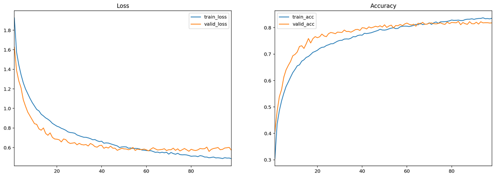

```python
print(checkpoint_epoch)
plot_train_stats(train_stats)
```

# Checkpoint

The model has been saved to disk.

## Test Model

Test your model against the test dataset. This will be your final accuracy. You should have an accuracy greater than 50%. If you don't, keep tweaking the model architecture and parameters.

```
INFO:tensorflow:Restoring parameters from ./image_classification
Testing Accuracy: 0.8140822784810127
```

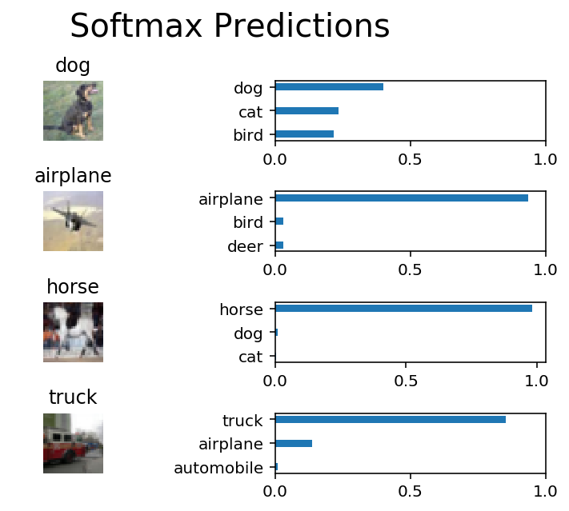

```python
"""
DON'T MODIFY ANYTHING IN THIS CELL
"""
%matplotlib inline
%config InlineBackend.figure_format = 'retina'

import tensorflow as tf
import pickle
import helper
import random

# Set batch size if not already set
try:
    if batch_size:
        pass
except NameError:
    batch_size = 64

save_model_path = './image_classification'
n_samples = 4
top_n_predictions = 3

def test_model():
    """
    Test the saved model against the test dataset
    """

    test_features, test_labels = pickle.load(open('preprocess_test.p', mode='rb'))
    loaded_graph = tf.Graph()

    with tf.Session(graph=loaded_graph) as sess:
        # Load model
        loader = tf.train.import_meta_graph(save_model_path + '.meta')
        loader.restore(sess, save_model_path)

        # Get Tensors from loaded model
        loaded_x = loaded_graph.get_tensor_by_name('x:0')
        loaded_y = loaded_graph.get_tensor_by_name('y:0')
        loaded_keep_prob = loaded_graph.get_tensor_by_name('keep_prob:0')
        loaded_logits = loaded_graph.get_tensor_by_name('logits:0')
        loaded_acc = loaded_graph.get_tensor_by_name('accuracy:0')

        # Get accuracy in batches for memory limitations
        test_batch_acc_total = 0
        test_batch_count = 0

        for test_feature_batch, test_label_batch in helper.batch_features_labels(test_features, test_labels, batch_size):
            test_batch_acc_total += sess.run(
                loaded_acc,
                feed_dict={loaded_x: test_feature_batch, loaded_y: test_label_batch, loaded_keep_prob: 1.0})
            test_batch_count += 1

        print('Testing Accuracy: {}\n'.format(test_batch_acc_total/test_batch_count))

        # Print Random Samples
        random_test_features, random_test_labels = tuple(zip(*random.sample(list(zip(test_features, test_labels)), n_samples)))
        random_test_predictions = sess.run(
            tf.nn.top_k(tf.nn.softmax(loaded_logits), top_n_predictions),
            feed_dict={loaded_x: random_test_features, loaded_y: random_test_labels, loaded_keep_prob: 1.0})
        helper.display_image_predictions(random_test_features, random_test_labels, random_test_predictions)


test_model()
```

## Why 50-80% Accuracy?

You might be wondering why you can't get an accuracy any higher. First things first, 50% isn't bad for a simple CNN. Pure guessing would get you 10% accuracy. However, you might notice people are getting scores [well above 80%](http://rodrigob.github.io/are_we_there_yet/build/classification_datasets_results.html#43494641522d3130). That's because we haven't taught you all there is to know about neural networks. We still need to cover a few more techniques.

## Submitting This Project

When submitting this project, make sure to run all the cells before saving the notebook. Save the notebook file as "dlnd_image_classification.ipynb" and save it as a HTML file under "File" -> "Download as". Include the "helper.py" and "problem_unittests.py" files in your submission.